# **Example: *ll_i2c_two_boards_com_polling_responder***

**Example version:** 2.0.3

[figure not shown]

How to handle an infinite number of transmit-receive transactions in polling mode between two boards based on the I2C-bus protocol with the LL API.

The example implements the responder’s code.

**Note that the terminology Controller/Responder characterizes the role taken by each device in the I2C communication, also known as I2C master and slave in legacy terminology.**

## **1. Detailed scenario**

**Initialization phase**: At main program start, the `mx_system_init()` function is called. It initializes the peripherals, nonvolatile memory (such as flash memory, NVM, or external memories), MPU regions (if applicable), the system clock, and the SysTick.

The application executes the following **example steps**:

**Step 1**: Initializes the I2C instance.

**Step 2**: The responder expects to receive a message as a null-terminated string from the controller board, in blocking mode, within a specific timeout period.

**Step 3**: The responder sends back the received message within the specified timeout period, in blocking mode. Returns to **Step2** indefinitely if no error occurs.

> *NOTE:* when an error occurs in the reception or transmission process, the responder restarts the reception process. The error_handler() function is called when the maximum number of attempts is reached and an error status is reported.

The communication status is reported via the status LED and the variable ExecStatus.

**End of example**: If no error occurs, the data is transferred infinitely between the controller and the responder.

## **2. Example configuration**

[figure not shown]

**I2C**: is configured as indicated below:

- The 7-bit addressing mode is selected. The responder’s own address is set to 0x3FU.
- The I2C IP is configured to run at the maximum supported speed to demonstrate its highest performance.
- The I2C-bus timings are calculated by STM32CubeMX2 in line with the I2C initialization section in the reference manual.
- The selected GPIO pins support the I2C alternate function. They are configured in open drain mode with no pull-up neither pull-down.

> *NOTE:* The I2C protocol standard requires to have a single pull-up resistor connected from each I2C line to the power supply to enable the communication. We have already pull-up resistors for the I2C pins on the controller’s board side. That is why in this use-case, we do not apply this configuration on the responder’s board side.

## **3. Hardware environment and setup**

### **3.1. Generic Setup**

The controller board is connected to the responder board through the two I2C lines and a common GND.

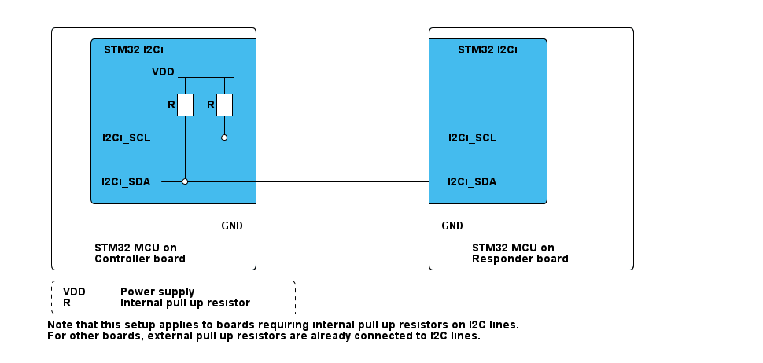

example_ll_i2c_two_boards_com_polling_responder-setup

### **3.2. Specific board setups**

The I2C serial clock (SCL) and data (SDA) lines can be observed by connecting an oscilloscope or a logic analyzer to the corresponding board connectors.

This section describes the exact hardware configurations of your project.

**On STM32C5 series.**

**On board NUCLEO-C542RC.**

| MCU pin | Signal name | User Label |
| --- | --- | --- |
| PH0 | RCC_OSC_IN | OSC_IN |
| PH1 | RCC_OSC_OUT | OSC_OUT |
| PB6 | I2C1_SCL | PB6 |
| PB7 | I2C1_SDA | PB7 |
| PA5 | GPIO | MX_STATUS_LED |

**On board NUCLEO-C562RE.**

| MCU pin | Signal name | User Label |
| --- | --- | --- |
| PH0 | RCC_OSC_IN | OSC_IN |
| PH1 | RCC_OSC_OUT | OSC_OUT |
| PB6 | I2C1_SCL | PB6 |
| PB7 | I2C1_SDA | PB7 |
| PA5 | GPIO | MX_STATUS_LED |

**On board NUCLEO-C5A3ZG.**

| MCU pin | Signal name | User Label |
| --- | --- | --- |
| PH0 | RCC_OSC_IN | PH0_OSC_IN |
| PH1 | RCC_OSC_OUT | PH1_OSC_OUT |
| PB6 | I2C1_SCL | PB6 |
| PB7 | I2C1_SDA | PB7 |
| PA5 | GPIO | MX_STATUS_LED |

## **4. Troubleshooting**

[figure not shown]

Here are the points of attention for this specific example:

1. The example needs to ensure that the controller sends the exact number of bytes expected by the responder.
2. If there are no I2C signals observed, remember to check these points first:
   - The GND pins of the controller and responder boards are connected.
   - pull-up resistors (internal or external) are applied for the selected I2C pins.
3. If the I2C signals observed do not comply with the I2C specification, especially at high frequencies, you should try the following tips:
   - Use the oscilloscope instead of the logic analyzer for a better measuring and viewing analog characteristics of the signals SCL and SDA. Check that the grounds of the instrument and the board are well wired.
   - Replace the internal pull-up resistors with external ones. The selected values of the resistors should be compliant with the I2C specification.
4. Note that the selected I2C timeout period of 3 seconds ensures a stable communication between the two boards and a reliable synchronization in different cases of controller or responder reset. Be sure to adjust its value carefully when needed.

**Error handling**: In LL examples, error handling is controlled by the USE_LL_APP_ERROR constant in the application files to reduce code footprint. This compilation flag is disabled by default. If the example does not behave as expected, enable error handling for debugging by setting USE_LL_APP_ERROR to 1 in ll_example.h.

**Timeout management**: Polling flag instructions can cause the example to enter an infinite loop. To prevent this, a timeout mechanism is implemented. When the timeout is reached, the program exits the loop and reports the error at the application level. This mechanism is controlled by the USE_LL_APP_TIMEOUT compilation flag, which is disabled by default to reduce code footprint. If the example execution appears to be stuck in an infinite loop, enable this mechanism for debugging by setting USE_LL_APP_TIMEOUT to 1 in ll_example.h.

## **5. See Also**

[figure not shown]

- You can find the application note AN10216-01 related to the I2C MANUAL on the [i2c-bus.org](https://www.i2c-bus.org/specification/) website if you want to go further on some technical details of the I2C bus (such as external pull-up resistors calculation for example).

The documentation of the drivers of the relevant STM32 series contains more detailed information.

For instance for the STM32C5 series: [HAL documentation](https://dev.st.com/stm32cube-docs/stm32c5xx-hal-drivers/latest/en/index.html).

More information about the STM32 ecosystem can be found in the [STM32 MCU Developer Zone](https://www.st.com/content/st_com/en/stm32-mcu-developer-zone/embedded-software.html).

## **6. License**

Copyright (c) 2026 STMicroelectronics.

This software is licensed under terms that can be found in the LICENSE file in the root directory of this software component. If no LICENSE file comes with this software, it is provided AS-IS.